# Introduction to Neural Networks: Bank Churn prediction

```python
## Complete the code to fit the model on train data and train the model with best batch_size obtained from hyperparameter tuning
history_hyper=estimator_v2.fit(X_train,
                           y_train,
                            epochs=100,
                           batch_size = grid_result.best_params_['batch_size'],
                           verbose=1,validation_data=(X_val,y_val))
```

**Loss function**

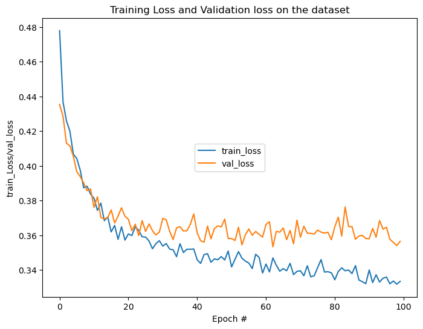

```python
N =100
plt.figure(figsize=(8,6))
plt.plot(np.arange(0, N), history_hyper.history["loss"], label="train_loss")
plt.plot(np.arange(0, N), history_hyper.history["val_loss"], label="val_loss")

plt.title("Training Loss and Validation loss on the dataset")
plt.xlabel("Epoch #")
plt.ylabel("train_Loss/val_loss")
plt.legend(loc="center")
plt.show()
```

**Threshold**

```
Best Threshold=0.239178, G-Mean=0.805
```

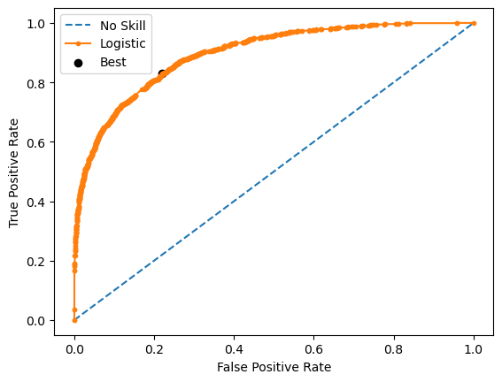

```python
# predict probabilities
yhat = estimator_v2.predict(X_train)
# keep probabilities for the positive outcome only
yhat = yhat[:, 0]
# calculate roc curves
fpr, tpr, thresholds = roc_curve(y_train, yhat)
# calculate the g-mean for each threshold
gmeans = np.sqrt(tpr * (1-fpr))
# locate the index of the largest g-mean
ix = np.argmax(gmeans)
print('Best Threshold=%f, G-Mean=%.3f' % (thresholds[ix], gmeans[ix]))
# plot the roc curve for the model
pyplot.plot([0,1], [0,1], linestyle='--', label='No Skill')
pyplot.plot(fpr, tpr, marker='.', label='Logistic')
pyplot.scatter(fpr[ix], tpr[ix], marker='o', color='black', label='Best')
# axis labels
pyplot.xlabel('False Positive Rate')
pyplot.ylabel('True Positive Rate')
pyplot.legend()
# show the plot
pyplot.show()
```

**Predict the results using the best threshold**

```python
# Complete the code to obtain the predictions on X_val
y_pred_h = estimator_v2.predict(X_val)
print(y_pred_h)
```

```
[[0.27173883]
 [0.00967249]
 [0.10280531]
 ...
 [0.14504635]
 [0.58835065]
 [0.4686341 ]]
```

```python
# To use the confusion Matrix, we need to convert the probabilities that a customer will leave the bank into the form true or false.
# So we will use the best cutoff value  to indicate whether they are likely to exit or not.
y_pred_h = (y_pred_h > thresholds[ix])
print(y_pred_h)
```

```
[[ True]
 [False]
 [False]
 ...
 [False]
 [ True]
 [ True]]
```

**Classification report**

```python
# Complete the code to obtain the classification report
cr=metrics.classification_report(y_val,y_pred_h)
print(cr)
```

```
              precision    recall  f1-score   support

           0       0.92      0.76      0.84      1274
           1       0.45      0.75      0.56       326

    accuracy                           0.76      1600
   macro avg       0.69      0.76      0.70      1600
weighted avg       0.83      0.76      0.78      1600
```

**Confusion matrix**

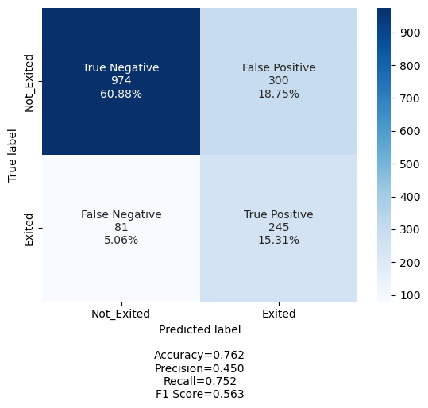

```python
## Complete the code to obtain the confusion matrix
cm_h=confusion_matrix(y_val, y_pred_h)

labels = ['True Negative','False Positive','False Negative','True Positive']
categories = [ 'Not_Exited','Exited']
model4_score = make_confusion_matrix(cm_h,
                      group_names=labels,
                      categories=categories,
                      cmap='Blues')
```

```python
print(model4_score)
```

```
Accuracy=0.762
Precision=0.450
Recall=0.752
F1 Score=0.563
```

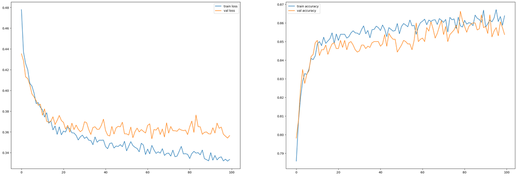

```python
# plot the accuracy and loss graphs for train and validation data

fig, (ax1, ax2) = plt.subplots(1, 2, figsize=(30, 10))
ax1.plot(history_hyper.history['loss'], label='train loss')
ax1.plot(history_hyper.history['val_loss'], label='val loss')

ax2.plot(history_hyper.history['accuracy'], label='train accuracy')
ax2.plot(history_hyper.history['val_accuracy'], label='val accuracy')

ax1.legend()
ax2.legend()
plt.show()
```

#### Observations:

- **Accuracy:** The accuracy of the model is 76.2%. This metric measures the proportion of correctly classified instances among all instances in the dataset.
- **Precision:** The precision of the model is 45.0%. Precision is the ratio of true positive predictions to the total positive predictions. It measures the accuracy of positive predictions made by the model.
- **Recall:** The recall of the model is 75.2%. Recall, also known as sensitivity or true positive rate, is the ratio of true positive predictions to the total actual positives. It measures the model's ability to identify positive instances correctly.
- **F1 Score:** The F1 score is 56.3%. The F1 score is the harmonic mean of precision and recall. It provides a balance between precision and recall, taking both false positives and false negatives into account.

```python
backend.clear_session()
#Fixing the seed for random number generators so that we can ensure we receive the same output everytime
np.random.seed(2)
random.seed(2)
tf.random.set_seed(2)
```

```python
## Complete the code to initilaize a sequential model
model_5 = Sequential()

# Complete the code to add a input layer of 32 neurons with relu as activation function
model_5.add(Dense(32,activation='relu',input_dim = X_train.shape[1]))

# Adding the first hidden layer with 16 neurons with relu as activation functions with dropout_rate= 0.2
model_5.add(Dropout(rate = 0.2))
model_5.add(Dense(16,activation='relu'))

# # Adding the second hidden layer with 8 neurons with relu as activation functions with dropout_rate= 0.1
model_5.add(Dropout(rate = 0.1))
model_5.add(Dense(8,activation='relu'))

# Adding the output layer
model_5.add(Dense(1, activation = 'sigmoid'))
```

```python
## Complete the code to obtain the summary of the model
model_5.summary()
```

```
Model: "sequential"
_________________________________________________________________
 Layer (type)                Output Shape              Param #
=================================================================
 dense (Dense)               (None, 32)                352

 dropout (Dropout)           (None, 32)                0

 dense_1 (Dense)             (None, 16)                528

 dropout_1 (Dropout)         (None, 16)                0

 dense_2 (Dense)             (None, 8)                 136

 dense_3 (Dense)             (None, 1)                 9

=================================================================
Total params: 1,025
Trainable params: 1,025
Non-trainable params: 0
_________________________________________________________________
```

```python
# Defining Early stopping
earlystopping = callbacks.EarlyStopping(monitor='val_loss', min_delta=0.001, patience=5)

# Initializing Adam optimizer
optimizer = tf.keras.optimizers.Adam(0.001)

# Complining the model with binary cross entropy as loss and accuracy as metrics
model_5.compile(optimizer = optimizer,loss = 'binary_crossentropy', metrics = ['accuracy'])

# Complete the code to fit the model on train with batch_size of 64, epochs of 100 and callbacks as earlystopping
history_balance = model_5.fit(X_train, y_train,batch_size=64,epochs=100,verbose=1,validation_data = (X_val,y_val),callbacks=[earlystopping])
```

```
WARNING:absl:At this time, the v2.11+ optimizer `tf.keras.optimizers.Adam` runs slowly on M1/M2 Macs, please use the legacy Keras optimizer instead, located at `tf.keras.optimizers.legacy.Adam`.
WARNING:absl:There is a known slowdown when using v2.11+ Keras optimizers on M1/M2 Macs. Falling back to the legacy Keras optimizer, i.e., `tf.keras.optimizers.legacy.Adam`.
```

**Loss function**

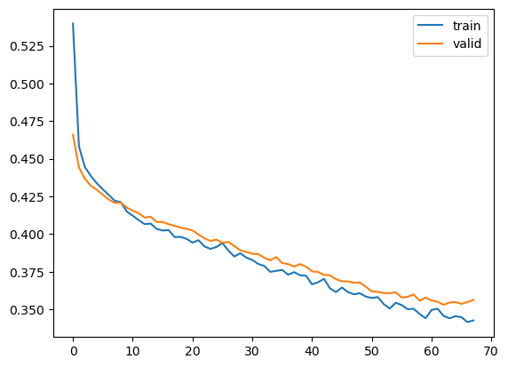

```python
# Capturing learning history per epoch
hist  = pd.DataFrame(history_balance.history)
hist['epoch'] = history_balance.epoch

# Plotting accuracy at different epochs
plt.plot(hist['loss'])
plt.plot(hist['val_loss'])
plt.legend(("train" , "valid") , loc =0)
```

**Finding the optimal threshold**

```
Best Threshold=0.238075, G-Mean=0.796
```

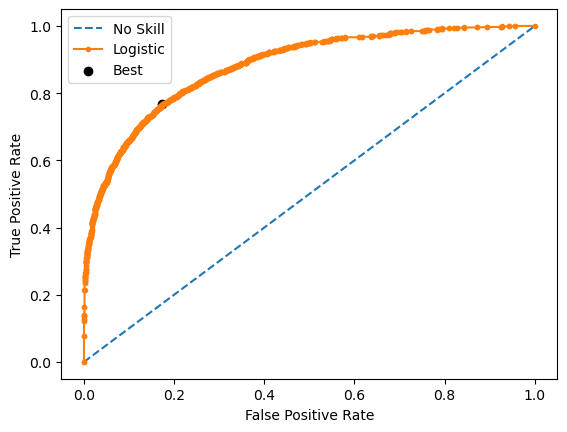

```python
## Complete the code to find the optimal threshold using X_train
yhat = model_5.predict(X_train)

# keep probabilities for the positive outcome only
yhat = yhat[:, 0]
# calculate roc curves
fpr, tpr, thresholds = roc_curve(y_train, yhat)
# calculate the g-mean for each threshold
gmeans = np.sqrt(tpr * (1-fpr))
# locate the index of the largest g-mean
ix = np.argmax(gmeans)
print('Best Threshold=%f, G-Mean=%.3f' % (thresholds[ix], gmeans[ix]))
# plot the roc curve for the model
pyplot.plot([0,1], [0,1], linestyle='--', label='No Skill')
pyplot.plot(fpr, tpr, marker='.', label='Logistic')
pyplot.scatter(fpr[ix], tpr[ix], marker='o', color='black', label='Best')
# axis labels
pyplot.xlabel('False Positive Rate')
pyplot.ylabel('True Positive Rate')
pyplot.legend()
# show the plot
pyplot.show()
```

```python
## Complete the code to obtain the predictions on X_val
y_pred_s = model_5.predict(X_val)
#Predicting the results using tuned threshold
y_pred_s = (y_pred_s >thresholds[ix])
y_pred_s
```

```
array([[ True],
       [False],
       [False],
       ...,
       [False],
       [ True],
       [ True]])
```

**Classification report**

```python
cr=metrics.classification_report(y_val,y_pred_s)
print(cr)
```

```
              precision    recall  f1-score   support

           0       0.92      0.81      0.86      1274
           1       0.48      0.71      0.58       326

    accuracy                           0.79      1600
   macro avg       0.70      0.76      0.72      1600
weighted avg       0.83      0.79      0.80      1600
```

**Confusion matrix**

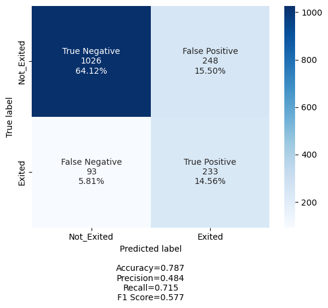

```python
#Calculating the confusion matrix
cm_s=confusion_matrix(y_val, y_pred_s)
labels = ['True Negative','False Positive','False Negative','True Positive']
categories = [ 'Not_Exited','Exited']
model5_score = make_confusion_matrix(cm_s,
                      group_names=labels,
                      categories=categories,
                      cmap='Blues')
```

```python
print(model5_score)
```

```
Accuracy=0.787
Precision=0.484
Recall=0.715
F1 Score=0.577
```

#### Observations:

- **Accuracy:** The accuracy of the model is 78.7%. This metric measures the proportion of correctly classified instances among all instances in the dataset.
- **Precision:** The precision of the model is 48.4%. Precision is the ratio of true positive predictions to the total positive predictions. It measures the accuracy of positive predictions made by the model.
- **Recall:** The recall of the model is 71.5%. Recall, also known as sensitivity or true positive rate, is the ratio of true positive predictions to the total actual positives. It measures the model's ability to identify positive instances correctly.
- **F1 Score:** The F1 score is 57.7%. The F1 score is the harmonic mean of precision and recall. It provides a balance between precision and recall, taking both false positives and false negatives into account.

```python
print('----- Model 1 -----',model1_score)

print('\n----- Model 2 -----',model2_score)

print('\n----- Model 3 -----',model3_score)

print('\n----- Model 4 -----',model4_score)

print('\n----- Model 5 -----',model5_score)
```

```
----- Model 1 -----

Accuracy=0.837
Precision=0.644
Recall=0.445
F1 Score=0.526

----- Model 2 -----

Accuracy=0.781
Precision=0.476
Recall=0.727
F1 Score=0.575

----- Model 3 -----

Accuracy=0.777
Precision=0.470
Recall=0.752
F1 Score=0.579

----- Model 4 -----

Accuracy=0.762
Precision=0.450
Recall=0.752
F1 Score=0.563

----- Model 5 -----

Accuracy=0.787
Precision=0.484
Recall=0.715
F1 Score=0.577
```

### Observations on the above models:

The choice of the best model depends on the specific priorities and requirements of the bank. Here's an analysis of the provided models:

**Model 1:**

- High accuracy (83.7%).
- Good precision (64.4%).
- Moderate recall (44.5%).
- Moderate F1 Score (52.6%).

**Model 2:**

- Moderate accuracy (78.1%).
- Balanced precision (47.6%) and high recall (72.7%).
- Good F1 Score (57.5%).

**Model 3:**

- Slightly lower accuracy (77.7%).
- Balanced precision (47.0%) and high recall (75.2%).
- Good F1 Score (57.9%).

**Model 4:**

- Lower accuracy (76.2%).
- Moderate precision (45.0%).
- High recall (75.2%).
- Moderate F1 Score (56.3%).

**Model 5:**

- Good accuracy (78.7%).
- Balanced precision (48.4%) and good recall (71.5%).
- Good F1 Score (57.7%).

Here are some considerations for model selection:

- If the bank prioritizes high accuracy and is less concerned about precision and recall balance, **Model 1** might be suitable due to its highest accuracy.
- If there's a need for a balance between precision and recall, **Model 2** and **Model 3** have good F1 scores, indicating a trade-off between the two.
- **Model 5** also offers a balance between precision and recall, with a good F1 score and competitive accuracy.

It's important to consider the specific goals of the bank. If the primary concern is to minimize false negatives (i.e., correctly identify customers who will leave), models with higher recall (e.g., Model 2, Model 3, Model 4) may be preferred. If a balance between precision and recall is desired, Model 5 is a good choice.

Ultimately, the decision should take into account the bank's business objectives, the cost of false positives and false negatives, and the trade-off between precision and recall. Additionally, it may be helpful to perform further testing and validation to ensure the model's performance aligns with the bank's specific requirements.

## Final Model

```
Best Threshold=0.238075, G-Mean=0.796
```

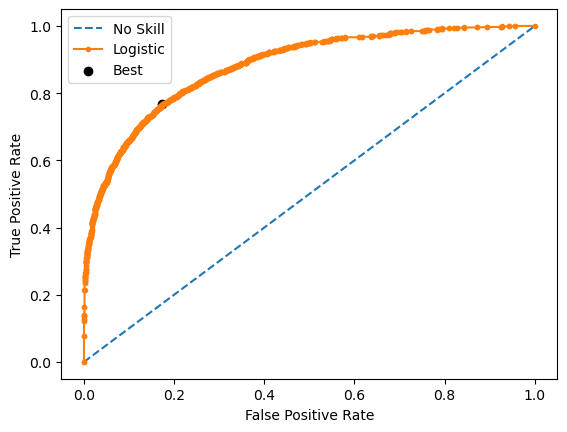

```python
# predict probabilities using the best model
yhat = model_5.predict(X_train)
# keep probabilities for the positive outcome only
yhat = yhat[:, 0]
# calculate roc curves
fpr, tpr, thresholds = roc_curve(y_train, yhat)
# calculate the g-mean for each threshold
gmeans = np.sqrt(tpr * (1-fpr))
# locate the index of the largest g-mean
ix = np.argmax(gmeans)
print('Best Threshold=%f, G-Mean=%.3f' % (thresholds[ix], gmeans[ix]))
# plot the roc curve for the model
pyplot.plot([0,1], [0,1], linestyle='--', label='No Skill')
pyplot.plot(fpr, tpr, marker='.', label='Logistic')
pyplot.scatter(fpr[ix], tpr[ix], marker='o', color='black', label='Best')
# axis labels
pyplot.xlabel('False Positive Rate')
pyplot.ylabel('True Positive Rate')
pyplot.legend()
# show the plot
pyplot.show()
```

```python
# Complete the code to Predict the X_test data using the best model
y_pred_test = model_5.predict(X_test)
y_pred_test = (y_pred_test > thresholds[ix])
print(y_pred_test)
```

```
[[False]
 [False]
 [False]
 ...
 [ True]
 [False]
 [False]]
```

**Classification report**

```python
## Complete the code to obtain the classification report on y_test and the predicted values
cr=metrics.classification_report(y_test,y_pred_test)
print(cr)
```

```
              precision    recall  f1-score   support

           0       0.92      0.80      0.86      1593
           1       0.49      0.74      0.59       407

    accuracy                           0.79      2000
   macro avg       0.71      0.77      0.72      2000
weighted avg       0.84      0.79      0.80      2000
```

**Confusion report**

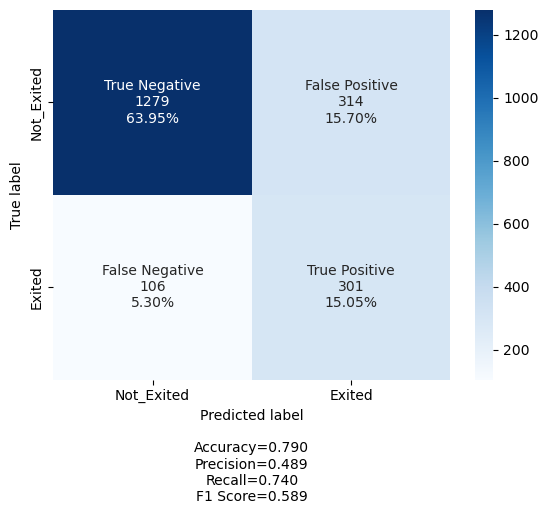

```python
# Complete the code to obtain the confusion matrix
cm_h=confusion_matrix(y_test, y_pred_test)
labels = ['True Negative','False Positive','False Negative','True Positive']
categories = [ 'Not_Exited','Exited']
final_model_score = make_confusion_matrix(cm_h,
                      group_names=labels,
                      categories=categories,
                      cmap='Blues')
```

```python
print(final_model_score)
```

```
Accuracy=0.790
Precision=0.489
Recall=0.740
F1 Score=0.589
```

## Actionable Insights and Recommendations

**What recommedations would you suggest to the bank?**

Based on the provided model performance with the following metrics:

- Accuracy: 79.0%
- Precision: 48.9%
- Recall: 74.0%
- F1 Score: 58.9%

Here are actionable insights and business recommendations for addressing customer churn in the bank:

1. **Identify High-Risk Customers:**
   - Leverage the model's recall (74.0%) to effectively identify high-risk customers who are more likely to churn. These customers require special attention and proactive measures to retain them.
2. **Enhance Customer Engagement:**
   - Focus on improving customer engagement strategies. Engaged customers are less likely to churn. Consider tailored communication, loyalty programs, and personalized offerings.
3. **Analyze Customer Feedback:**
   - Gather and analyze customer feedback to identify areas of improvement. Customer surveys and feedback forms can provide valuable insights into what aspects of the service need enhancement.
4. **Segment Customers:**
   - Segment customers based on their behavior, demographics, and other relevant factors. Customize retention strategies for different customer segments to address their unique needs.
5. **Retention Campaigns:**
   - Develop targeted retention campaigns for customers with a high risk of churning. These campaigns can include special offers, discounts, or personalized incentives.
6. **Churn Prediction System:**
   - Integrate the model into a real-time churn prediction system. Continuously monitor customer behavior and use the model to predict potential churn, allowing for timely intervention.
7. **Feedback Loop:**
   - Create a feedback loop to track the effectiveness of retention strategies. Monitor customer responses to different initiatives and adjust strategies as needed.
8. **Customer Support and Service Quality:**
   - Ensure excellent customer support and service quality. Customers who have positive experiences are less likely to leave. Train and motivate staff to provide outstanding service.
9. **Evaluate Product Portfolio:**
   - Assess the range of products and services offered. Consider diversifying or enhancing offerings to meet changing customer needs and preferences.
10. **Competitive Analysis:**
    - Regularly analyze the competitive landscape to stay informed about what competitors are offering. Ensure your services remain competitive and meet customer expectations.
11. **Use Customer Data Wisely:**
    - Leverage customer data responsibly and ethically. Understand customer preferences and behaviors to make informed decisions on service improvements.
12. **A/B Testing:**
    - Conduct A/B testing for different strategies to assess their impact on customer retention. Use data-driven insights to refine and optimize these strategies.
13. **Customer Education:**
    - Educate customers about the value of your services and how to make the most of them. Informed and engaged customers are more likely to stay.
14. **Employee Engagement:**
    - Engage and motivate bank employees. Happy and motivated staff often provide better service and contribute to customer satisfaction.
15. **Monitor Model Performance:**
    - Continuously monitor and assess the model's performance to ensure its accuracy and relevance. Update the model as needed to reflect changing customer behaviors.

It's essential to adopt a proactive and data-driven approach to reduce customer churn. The model's predictive power can serve as a valuable tool to identify potential churners, but the success of retention efforts ultimately relies on a combination of strategies and the commitment of the bank to customer satisfaction and loyalty.